# Notebook

## **Enhancing Urban Tree Planting through Air Quality Analysis**

**Authored by:** Vamshi Krishna Y R

### **Use case scenario**

**As a:** Resident of Melbourne who values sustainable city living and concerned about air pollution and its impact on daily health and wellbeing.

**I want to:** See key roadside areas in the city selected for tree planting projects based on their potential to reduce airborne pollutants.

**So that I can:** Breathe cleaner air in urban spaces, benefiting from reduced exposure to traffic-related emissions and a healthier living environment.

**By:**

- Analysing microclimate sensor data to identify areas along Melbourne’s roadways with poor air quality and high exposure to vehicular emissions.
- Mapping these pollution-prone zones against existing tree canopy data to locate streets with minimal natural filtration and shade coverage.
- Integrating tree planting zone data to pinpoint feasible locations for vegetation expansion that align with municipal greening regulations and infrastructure constraints.
- Selecting tree species with high pollutant absorption capabilities and modelling their expected impact on local air quality over time.
- Applying geospatial analysis to overlay environmental indicators—such as pollutant levels, canopy gaps, and permissible planting areas—to inform strategic decision-making.

### **What this use case will teach you**

- This use case explores how to integrate diverse urban datasets—specifically microclimate sensor readings, tree canopy coverage, and planting zone data—to identify roadside locations where strategic tree planting can significantly improve air quality. By engaging with real-world environmental data, you will address pressing urban health challenges related to pollution exposure.
- You will gain practical experience in applying geospatial analysis and leveraging microclimate insights to support data-informed decisions in sustainable urban planning.
- The case study focuses on techniques for assessing how vegetation coverage, pollutant concentrations, and permissible planting zones intersect, equipping you with the tools to prioritise greening interventions that deliver measurable air quality benefits.
- A key learning outcome will be the development of user-friendly dashboards and interactive visualisations to effectively communicate findings to stakeholders such as urban planners, environmental agencies, and community members.
- You will also learn to evaluate the environmental and societal implications of targeted greening projects, enabling you to propose data-driven strategies for creating healthier, more breathable urban environments.

### **Project Goals and expected outcomes**

- This project showcases the capability to integrate and analyse multiple open datasets—specifically microclimate sensor data, existing tree canopy coverage, and designated planting zones—to identify roadside locations where new tree plantings can most effectively improve urban air quality.
- The analysis will involve spatial and environmental evaluations to prioritise streets and road corridors that currently experience high levels of air pollution and lack sufficient vegetation. These assessments will guide decisions around optimal placement and species selection to maximise air filtration benefits.
- The goal is to deliver actionable insights that contribute to cleaner urban air by enhancing tree coverage in strategically selected areas. The project supports Melbourne’s broader objectives for sustainability, public health, and environmental resilience.
- A central output will be the development of an interactive, user-focused dashboard that visualises pollutant levels, canopy gaps, and suitable planting zones. This tool will empower urban planners, environmental stakeholders, and policymakers to make data-informed decisions.
- Ultimately, the project aims to provide clear, evidence-based recommendations for improving air quality through targeted urban greening—enhancing both the environmental performance of city streets and the everyday wellbeing of Melbourne’s residents.

## Data Analysis and Visualisation

**Tree Canopies 2021 dataset**

The below visualisation of illustrates the spatial extent of tree canopy coverage across Melbourne by transforming polygon data into geospatial geometries. The processed shapes were plotted on a static map to highlight zones with dense vegetation.

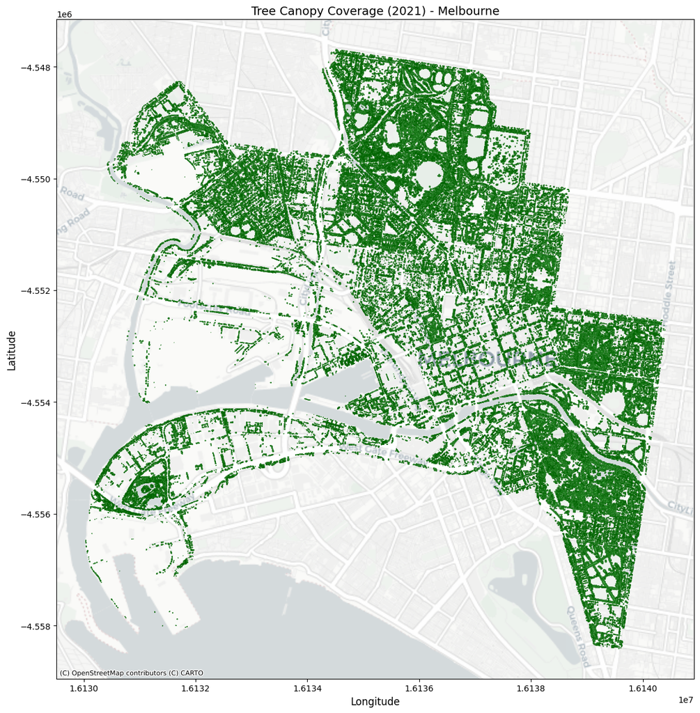

The chart shows a dense distribution of tree canopies in specific parts of the region, highlighted in green. These visualisations are required for identifying areas that already have substantial green coverage and pinpointing regions that require further intervention to enhance urban greenery. This analysis supports strategic planning for biodiversity conservation, reduction of urban heat islands, and improving the quality of public spaces.

In the below visualisation, segmenting the geographic area into a grid by binning both `latitude` and `longitude` values, then counting how many tree canopy points fall into each grid cell. These counts are visualised as a 2D heatmap, where darker green shades represent higher tree canopy density across Melbourne.

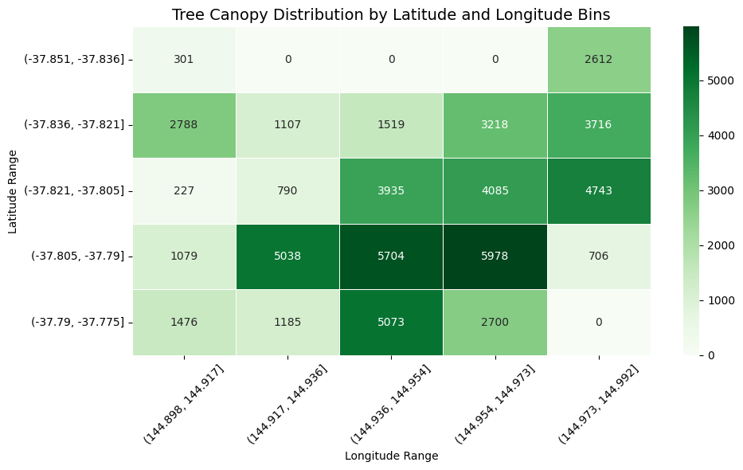

These insights provides a view of canopy density in different pockets of the city.

**Microclimate Sensor dataset**

The figure shows each sensor’s position with a 50 m buffer around it. Next, we will assess how the tree canopy within these 50 m zones influences local pollution levels.

[figure not shown]

The box-and-whisker format helps identify both the typical range (the box) and the more extreme daily averages (the whiskers and any outliers). The taller boxes or higher medians tend to have more elevated PM2.5 levels or wider day-to-day fluctuations. The spread of the boxes reveals how stable or variable temperatures are on a daily basis, and outliers may point to unusual temperature spikes or dips on specific days.

[interactive chart not shown]

**Distribution of Average PM2.5 per Month Across Devices:**

The box plot displays the distribution of average PM2.5 levels across different months for all devices. It highlights the central tendency and variability in pollution levels, clearly showing which months record higher or lower PM2.5 concentrations. Observations from this plot reveal that the months from December to March, likely influenced by the summer season, exhibit a higher median PM2.5. Additionally, the plot shows noticeable outliers, indicating that on certain days, there are unexpected spikes in pollution levels. These variations could be due to transient local events or differences in microclimate conditions across sensor locations.

Building upon the previous analysis, we narrow our focus to January—the month with the highest PM2.5 levels. The dataset is filtered to include only January's records, and a new date column is created to group data by each day. For every device, daily averages for PM2.5 is computed, providing a more granular view of environmental conditions. This detailed approach reveals short-term fluctuations and local effects that might be obscured in broader monthly averages, offering deeper insights for targeted urban and pollution management strategies. Additionally, the analysis aims to observe the variance across all devices to determine whether the differences in daily averages are consistent or if certain locations exhibit significantly different patterns.

[interactive chart not shown]

**Average PM2.5 in January Across Devices:**

This box plot clearly indicates that PM2.5 readings vary significantly among devices. Some devices consistently record higher median pollution levels with minimal variability, while others show wider ranges and occasional spikes. This suggests that certain locations are more prone to higher pollution levels, likely due to local factors that contribute to uneven distribution. Overall, the box plot offers detailed insights into daily environmental conditions across devices in January, highlighting the differences that are critical for targeted urban and pollution management strategies.

**Tree Planting Zone dataset**

The following analysis examines tree planting data through a visual summary that highlights the distribution of segment or zone counts across different project schedules. The data is grouped by project timeframes to provide clear insights into how many segments or zones are at each stage. Custom ordering of the `schedule` column enhances readability and ensures the visualisation delivers more meaningful insights.

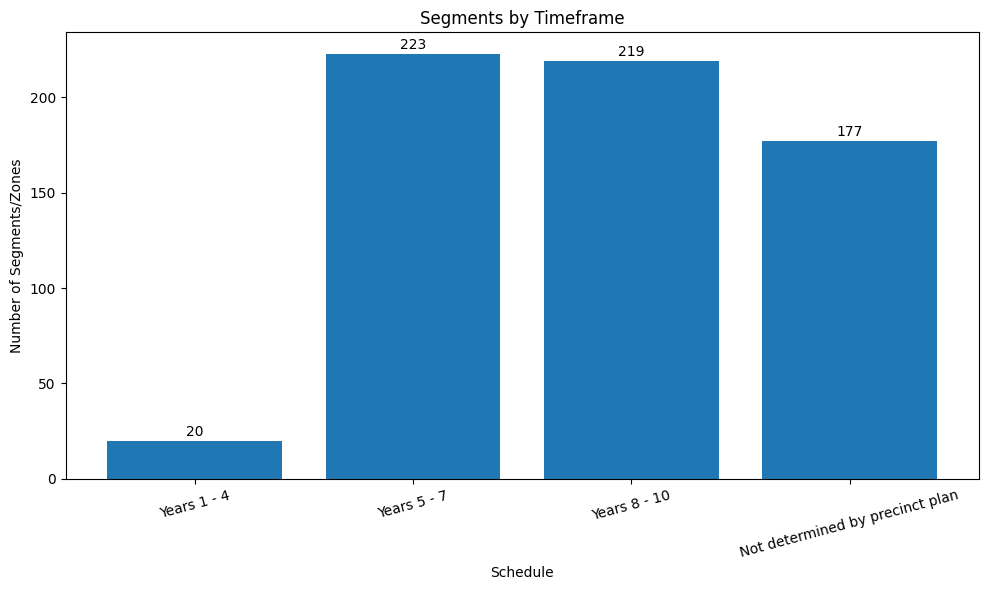

The process begins by verifying that essential location details (longitude and latitude) are available, as these are crucial for accurately plotting the zones on a map. Once confirmed, the data is transformed to align with Melbourne’s mapping system, ensuring each planting zone appears in its correct location. The zones are then colour-coded based on their project schedule, enabling quick visual differentiation of their progress. Finally, a background map of Melbourne is added, providing familiar context and making it easier to understand the spatial distribution and planning of the tree planting projects.

```
Labeling top 20 zones by PM2.5 reduction out of 639 total zones
```

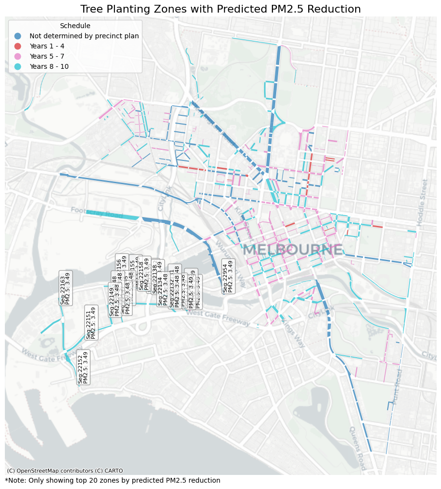

**Tree Planting Zones with Predicted PM2.5 Reduction Potential**

## Observations and Conclusions

### Key Findings

#### Spatial Patterns

- Sensors recorded widely varying PM2.5 levels depending on location, suggesting microclimate effects
- The existing tree canopy is unevenly distributed, creating opportunities for targeted planting
- Areas with higher tree canopy density within 50m of sensors showed measurable reductions in PM2.5 levels

#### Implementation Timeline

- Trees typically begin providing initial PM2.5 reduction within 2-3 years of planting, with measurable significant improvements observed after 5-7 years as canopies develop. This timeline should be factored into planning.
- The majority of planting zones are scheduled for mid-term (Years 5-7: 223 zones) and long-term (Years 8-10: 219 zones) implementation
- Only 20 zones are scheduled for immediate action (Years 1-4)
- 177 zones remain without a determined implementation timeline which needs attention

### Modeling Approach

The blended ensemble of Random Forest and XGBoost models achieved an R² of approximately 0.6, demonstrating that local tree canopy area combined with meteorological variables explains a significant portion of PM2.5 variability, while leaving room for other environmental factors.

### Recommendations

- **Implementation Timeline**: Consider that newly planted trees require time to mature before delivering full air quality benefits.
- **Plan Undetermined Zones**: Establish concrete implementation schedules for the 177 zones currently lacking defined timelines. These represent nearly 28% of all planting zones and should be evaluated based on their potential PM2.5 reduction impact and integrated into the comprehensive urban forest strategy with clear target dates.
- **Prioritisation**: Focus on zones with highest predicted PM2.5 reduction potential, particularly those in Years 5-10 timeframes
- **Strategic Planning**: Consider accelerating implementation in high-impact areas currently in Years 8-10
- **Adaptive Management**: Continue sensor monitoring and model refinement to optimise outcomes as trees mature and environmental conditions evolve, allowing for data-driven adjustments to planting strategies and maintenance routines based on real-world performance measurements
- **Further Research**: Explore additional variables that might explain the remaining variance in PM2.5 reduction

By implementing these recommendations, Melbourne's urban forest strategy can maximise air quality benefits while creating a more resilient, sustainable urban environment.

## References

1. Vaishali, Verma, G. & Das, R.M. (2023) ‘Influence of Temperature and Relative Humidity on PM₂.₅ Concentration over Delhi’, MAPAN, 38, pp. 759–769. doi: 10.1007/s12647-023-00656-8 : https://link.springer.com/article/10.1007/s12647-023-00656-8.
2. Zhang, H., Wang, Y., Jianlin, H., Ying, Q. & Xiao-Ming, H. (2015) ‘Relationships between meteorological parameters and criteria air pollutants in three megacities in China’, Environmental Research, 140, pp. 242–254 : https://link.springer.com/article/10.1007/s12647-023-00656-8.
3. City of Melbourne (2021) *Tree Canopies 2021 Dataset*. Available at: https://data.melbourne.vic.gov.au/explore/dataset/tree-canopies-2021.
4. City of Melbourne (2023) *Tree Planting Zone Dataset*. Available at: https://data.melbourne.vic.gov.au/explore/dataset/tree-planting-zone.
5. City of Melbourne (2023) *Microclimate Sensor Data*. Available at: https://data.melbourne.vic.gov.au/explore/dataset/microclimate-sensor-readings.
6. Open-Meteo.com (2023) *Historical Weather API*. Available at: https://open-meteo.com/en/docs/historical-weather-api.